# Ćwiczenie6

#### Zadanie9: Czy fakt, że nie oczyściliśmy danych ze stopwords czy znaków interpunkcyjncyh znacząco wpłynął na pogorszenie predykcji? Odpowiedź uzasadnij (bez obliczeń, chodzi o 2 zdania komentarza).

#### Zadanie10: Powtórz 20 razy predykcję za pomocą metody Naive Bayes za każdym razem tasując listę documents (po co?). Zapisz do listy dokładności uzyskane za każdym razem. Wyznacz średnią dokładność i odchylenie standardowe z tych dokładności (wcześniej przerób listę na obiekt typu array). Narysuj histogram dokładności.

#### Zadanie11: Wyjaśnij czemu istotnym jest aby grupy tekstów reprezentujących klasy były w miarę równoliczne. Zbuduj model NaiveBayes, gdzie jako zbiór testowy wybierz 900 recenzji pozytywnych i 100 negatywnych. Następnie zabadaj jak model sprawdza się na 100 pozostałych recenzjach pozytywnych a jak na 100 negatywnych (innych niż przy trenowaniu modelu). Skomentuj otrzymane wyniki.

#### Zadanie12: Zbuduj model do predykcji wiadomości SPAM/HAM. W tym celu użyj pliku $spam\_ham.txt$. Każda wiadomość opatrzona jest odpowiednim tagiem na początku kolejnego wiersza. Sprawdź ile w pliku znajduje się wiadomości typu SPAM i HAM. Uwzględnij uwagę z poprzedniego zadania.

## Elementy statystyki i prezentacji danych

```python
import numpy as np #biblioteka obiektow typu array i pozwalająca przeprowadzic operacje na nich

x = np.array([1,2,5,6,2,2,4,1,5,5,3,3,4,5,6]) #nowy typ danych, cos jak lista ale ma nowe metody, będzie jeszcze o tym w przyszlosci
```

```python
type(x) #jaki typ
```

```
numpy.ndarray
```

```python
x[-1] #ostatni element
```

```
6
```

```python
x[0:4] #elementy 0,1,2,3
```

```
array([1, 2, 5, 6])
```

```python
np.mean(x) #średnia
```

```
3.6
```

```python
np.std(x) #odchylenie standardowe
```

```
1.6653327995729061
```

```python
np.median(x) #mediana
```

```
4.0
```

```python
np.sum(x)  #suma elementow
```

```
54
```

#### Porównanie obiektów typu listy i array

```python
x = [1,2,3]
y = [4,5,6]

print(x+y)
print(3*x)
```

```
[1, 2, 3, 4, 5, 6]
[1, 2, 3, 1, 2, 3, 1, 2, 3]
```

```python
x = np.array([1,2,3])
y = np.array([4,5,6])

print(x+y)
print(3*x)
```

```
[5 7 9]
[3 6 9]
```

```python
#Z obiektem typu array moge zrobic cos czego z listą absolutnie mi nie wolno

x = np.array([1,2,3,4,5])
y = x**2 + np.sin(x)
print(y)
```

```
[ 1.84147098  4.90929743  9.14112001 15.2431975  24.04107573]
```

#### Rysowanie wykresów

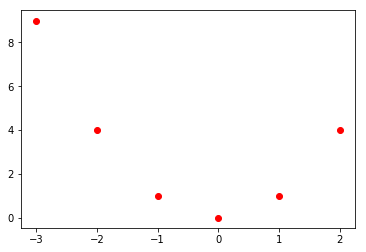

```python
import matplotlib.pyplot as plt #biblioteka do rysowania wykresow

a = np.array([-3,-2,-1,0,1,2])
b = a**2

#Rysowanie
plt.scatter(a,b, c = "red") #to samo co wyzej, tyle ze tym razem nie łączy punktow
plt.show()
```

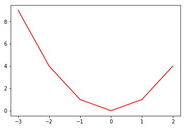

```python
plt.plot(a,b, c = "red") #to samo co wyzej, tyle ze tym razem łączy punkty
plt.show()
```

```python
x =  np.random.rand(1000) #generuje 1000 liczb z rozkładu jednostajnego
y =  np.random.randn(1000) #generuje 1000 liczb z rozkładu normalnego (Gaussa)
```

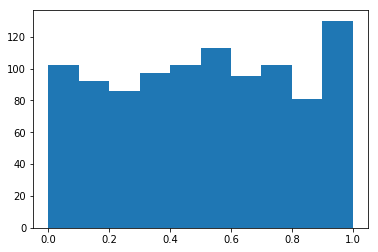

```python
#Rysuje histogram dla x
plt.hist(x)
plt.show()
```

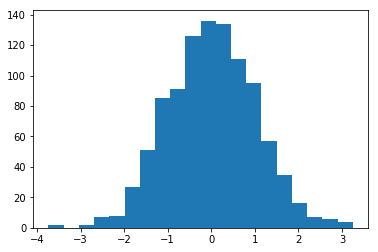

```python
#Rysuje histogram dla y
plt.hist(y, bins = 20) #parametr bins - ile pudełek ma być widocznych na rysunku
plt.show()
```

## Serializacja (zapisywanie obiektu)

```python
import pickle

t = [1,2,3,4,5]

#zapisywanie listy [jako obiektu!!!] do pliku
save_list = open("my_list.pickle","wb") #w-write, b -bity
pickle.dump(t, save_list)
save_list.close()
```

```python
#otwieranie
f = open("my_list.pickle","rb")
moja_lista = pickle.load(f)
f.close()
```

```python
print(moja_lista)
```

```
[1, 2, 3, 4, 5]
```

#### Zadanie13: Zapisz do pliku utworzony poprzednio model (znajdujący się w pod zmienną $classifier$).